# Teaching AI the Way We Teach Data Science

Open, hands-on, built to scale

Eric Van Dusen

College of Computing, Data Science, and Society, UC Berkeley

2026-10-09

## Teaching AI the Way We Teach Data Science

Open, hands-on, built to scale

**Eric Van Dusen**  
College of Computing, Data Science, and Society, UC Berkeley  
October 9, 2026  
github.com/ericvd-ucb

[figure not shown]

## The Data 8 Story

[figure not shown]

1. What do we know works?

A first course in computing and statistics, for any major, in the browser, with real data from day one.

*Largest course at UC Berkeley - up to 50% of undergraduates take it, and the gateway to Berkeley’s biggest major.*

[figure not shown]

inferentialthinking.com

We didn’t make students learn all the machinery before we let them do data science.

## The notebook became the laboratory

1. What do we know works?

- Browser
- Notebook
- Data
- Experiment
- Jupyter + Python + real data
- Change code, immediately see what happens
- Same environment for instructors and students
- Reproducible across a class
- Works for 20 students or thousands
- Open-source tools + open curriculum + shared infrastructure

## Three lessons from a decade of scaling

1. What do we know works?

### Remove friction

JupyterHub means no installs and no laptop gap. Students meet ideas before they fight environments.

### Connect to disciplines

Connector courses (like Data 88E) provide domain context that makes methods stick.

### Open everything

Github Deployment, Open Stack of tools, Open textbook, notebooks, and autograding are what let it travel.

## Scale is more than course materials

1. What do we know works? How to get 25 community colleges to adopt it?

- **Infrastructure:** shared JupyterHubs through for less resourced institutions ( eg NSF Cloudbank or Cal-ICOR)
- **Curriculum:** open materials community colleges can adopt and adapt
- **People:** faculty networks, workshops training, and credit that transfers

How much of this can we do for AI education?

## What if we did the same thing with AI?

2. Can we adapt what we teach?

### Put a model in the notebook.

- Prompt it
- Change parameters
- Examine tokens and probabilities
- Create embeddings
- Add retrieval
- Compare models
- Build evaluations
- Investigate failures

The notebook can become a laboratory for AI.

## Who owns the laboratory?

2. Can we adapt what we teach?

### Commercial AI

- Notebook
- API
- Proprietary model
- Commercial cloud

Student learns to **consume** AI

### Open-weight models on an open stack

- Notebook
- Open-source tooling
- Open model
- Shared / public compute

Student can **inspect, modify, evaluate and build**

## Small Open Models as teaching tools

2. Can we adapt what we teach?

You don’t need a frontier model for every experiment. A small open model is just a file students can count, inspect, and test.

- Parameters × bits ÷ 8 = size
- Tokens and next-token probabilities
- Temperature: what “randomness” means
- The linear algebra underneath
- “harness” - feed data in, get data out with data manipulation

```python
from transformers import AutoTokenizer, AutoModelForCausalLM

name = "HuggingFaceTB/SmolLM2-135M"   # a 270 MB file
tok = AutoTokenizer.from_pretrained(name)
lm = AutoModelForCausalLM.from_pretrained(name)

ids = tok("Amsterdam is famous for its", return_tensors="pt")
probs = lm(**ids).logits[0, -1].softmax(-1)

for p, i in zip(*probs.topk(5)):
    print(tok.decode(i), f"{p:.0%}")
```

[figure not shown]

## Small Models in a Jupyter Hub

2. Can we adapt what we teach?

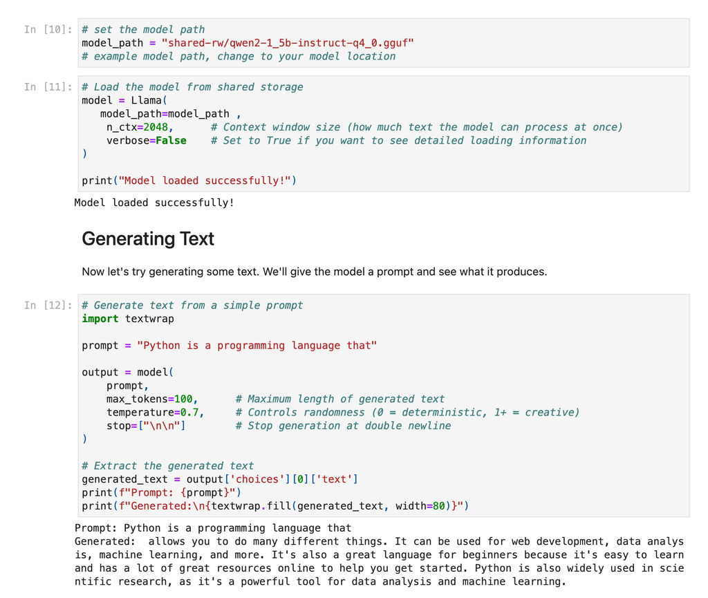

The model downloads into a shared location on *JupyterHub* and runs in browser. Students can inspect the model, change parameters, and see what happens, e.g. with no setup.

**Admin sets up environment, prof sets up curriculum, student explores.**

[Cloudbank Classroom](https://www.cloudbank.org/training/access-cloudbank-classroom): cloudbank.org/training/access-cloudbank-classroom

## Small Models in the Browser

2. Can we adapt what we teach?

[figure not shown]

**Try it now**

[jupyterlite.github.io/ai](https://jupyterlite.github.io/ai/lab/index.html)

[figure not shown]

The whole notebook, and the model, runs on your own laptop. **No account. No server. No cost.**

- **jupyterlite-ai**: chat and code completion inside JupyterLite
- **Pyodide**: Python compiled to WebAssembly
- **WebLLM**: LLMs on your GPU through WebGPU
- **Transformers.js**: Hugging Face models in the browser
- **wllama**: llama.cpp compiled to WebAssembly

Thanks to Jeremy Tuloup!

## From algorithms to systems

2. Can we adapt what we teach?

### What counts as technical literacy?

Traditional computing / ML

- Programming
- Mathematics
- Data structures
- Algorithms
- Machine learning

Modern AI workflow

- Data
- Models
- APIs
- Containers
- Cloud
- Deployment
- Evaluation
- Monitoring

## Students need to see the whole stack

2. Can we adapt what we teach?

A student can understand **gradient descent** but have no idea how an AI application actually works.

A student can now build an **AI application** without understanding gradient descent.

Both are educational problems.

- Data engineering
- APIs
- Containers and reproducible environments
- Cloud / GPUs / inference
- MLOps / LLMOps
- Evaluation and monitoring

**Teach enough engineering that the system stops looking like magic.**

## Same notebook, three rungs

3. What investments do we need?

1

### Browser

JupyterLite

Small models run on the student’s own laptop. Free, private, zero setup.

2

### Campus hub

JupyterHub

Shared model folders, curated environments, GPUs when a course needs them.

3

### HPC and cloud slices

Jupyter as the front door

A small allocation for every student who needs one. Powerful but hard to use today, so **invest in making it easy**.

**Teach the stack along the way:** environments, containers, git, job schedulers, cloud costs. DevOps is part of AI literacy.

## The model question

3. What investments do we need?

- Today’s small open models come mostly from a few labs, mostly China
- Corporate openness can change with the next release ( e.g. OpenAI, Google, Meta)
- Build open curriculum that is flexible enough to swap models in and out, but worth having a small open model that is always available for teaching

## Why small open models?

3. What investments do we need?

### Environment

Data centres used about **485 TWh** last year, roughly as much as Germany, and the IEA expects that to **double by 2030**. Communities are pushing back over power and water.

### Carbon and efficiency

Laptops and campus servers use little power when idle and need little cooling. Open-weight models trail the frontier by only **about four months**.

### Sovereignty

Models on institutional servers keep control of the tools, the data and privacy. Subsidized AI-for-rent **can’t last indefinitely**.

“Educators can train students not only how to use AI models, but also how to determine when local models are preferable to cloud-based systems.”

Buhler, Pérez & Boettiger, “[Scientists should shift away from AI data centres](https://www.nature.com/articles/d41586-026-02451-2)”, *Nature* 656, 296–298 (2026)

## Small + Open + Public

3. What investments do we need?

Europe doesn’t have to win the race for the **biggest model**.

It can compete differently, and it already has pieces at every rung.

Plus a mandate: AI literacy under Article 4 of the EU AI Act

| Rung | European pieces |
| --- | --- |
| Browser | QuantStack, JupyterLite |
| Campus hub | SURF and national research infrastructure |
| Public compute | EuroHPC |
| Models | GPT-NL, OpenEuroLLM |

Can Europe build a lighter-weight, open AI ecosystem rather than simply reproducing the hyperscalers?

## What should the university build?

3. What investments do we need?

**Students across the disciplines**

**Open curriculum**

**Interactive notebooks**

**Open-source tooling**

**Open models**

**Public / shared compute**

**Goal 1:** shared open **curriculum** that runs at multiple levels and can move between universities.

**Goal 2:** a small, fully open, multilingual **teaching model** with documented data.

## Data Science to AI

### Interactive pedagogy

We know how to make technical ideas accessible through **exploration**.

### Systems literacy

Students need to understand **workflows**, not only algorithms.

### Open infrastructure

Universities should help students become **builders**, not simply customers.

We are still scaling data science. Next: give everyone the ability to look inside AI.

**For the panel:** who should own the infrastructure that teaches the next generation what AI is?

ericvd@berkeley.edu · github.com/ericvd-ucb